# Meta analysis - rank product method

A. Nohturfft

2020-07-16

## Objective

Perform meta analysis of TB microarray AND RNA-seq data using the Rank Sum approach.  
Overview:

1. Microarray data: load log(fold change) data that Diana generated with Geo2r
2. RNA-seq data: load published tables
3. Aggregate microarray data by gene symbol; where the same gene is represented by several probes, calculate the **median** log(fold change)
4. Merge fold change data from all datasets into a single matrix (**outer join**)
5. Filter out genes with missing values (NA): keep only genes with a maximum number of missing values
6. In each dataset rank genes by fold change (convert fold changes to ranks; NAs stay NAs; maximum ranks will vary by NA count)
7. Replace NAs with average ranks in the other datasets
8. Now rank again so number of ranks in each dataset is the same
9. Calculate **rank sum** statistics and p values using RankProd package
10. Generate heatmaps of top 100 regulated genes

```r
# CHECK R VERSION
# stopifnot(R.version.string == "R version 3.4.3 (2017-11-30)")

# CLEANUP
# Clear all variables:
rm(list=ls(all=TRUE))

# Unload current packages:
# if (!is.null(names(utils::sessionInfo()[["otherPkgs"]]))) pacman::p_unload("all")
```

```r
# KNITR DEFAULTS
knitr::opts_chunk$set(eval = TRUE, fig.height = 10)
```

```r
# LOAD PACKAGES:
if (!requireNamespace("BiocManager", quietly = TRUE)) install.packages("BiocManager")
if (!requireNamespace("ComplexHeatmap", quietly = TRUE)) BiocManager::install("ComplexHeatmap")
if (!require(stringr)) install.packages("stringr")
if (!require(rstudioapi)) install.packages("rstudioapi")
if (!require(tidyr)) install.packages("tidyr")
if (!require(tibble)) install.packages("tibble")
if (!require(readxl)) install.packages("readxl")
if (!require(purrr)) install.packages("purrr")
if (!require(RColorBrewer)) install.packages("RColorBrewer")
if (!require(devtools)) install.packages("devtools")
if (!require(magrittr)) install.packages("magrittr")
if (!require(dplyr)) install.packages("dplyr")
if (!require(scales)) install.packages("scales")
if (!require(knitr)) install.packages("knitr")
if (!require(kableExtra)) install.packages("kableExtra")
if (!requireNamespace("RankProd", quietly = TRUE)) BiocManager::install("RankProd")

library(magrittr)
library(dplyr)
library(scales)
library(knitr)
library(kableExtra)
library(RankProd)
```

```r
# GET CURRENT SCRIPT NAME
(this.script <- rstudioapi::getActiveDocumentContext() %>% .$path %>% basename)
getwd()
list.files()
stopifnot(this.script != "")
```

## Data: microarray studies

### Geo2r data files

```r
geo2r.data.files <- list.files(path="../source_data", recursive = T,
                               pattern="^GSE.*Geo2r.*txt$", full.names = T)
geo2r.data.files <- grep(pattern = "GSE108363", geo2r.data.files, invert = T, value = T)
cat(basename(geo2r.data.files), sep="<br>\n")
```

```r
tailleux.data.files <- list.files(path="../source_data", recursive = T,
                                  pattern="*tailleux.*txt", full.names = T)
cat(basename(tailleux.data.files), sep="<br>\n")
```

```r
muarray.data.files <- c(geo2r.data.files, tailleux.data.files)
muarray.data.files <- grep("GSE29731", muarray.data.files, invert = T, value=T)
cat(basename(muarray.data.files), sep="<br>\n")
```

GSE103092_Geo2r_symbols.txt  
GSE34151_Geo2r.txt  
02_tailleux_18hrs_a.Rmd.tt.DC.2020_05_22.txt  
02_tailleux_18hrs_a.Rmd.tt.MP.2020_05_22.txt

### Load Geo2r data

```r
geo2r.data.list <- lapply(muarray.data.files, function(f) {
  a <- read.table(f, sep="\t", header=T, quote='"', stringsAsFactors = F)
  names(a)[grep("symbol", names(a), ignore.case = T)] <- "Gene.symbol"
  names(a) <- stringr::str_remove(names(a), "^X\\.")
  names(a) <- stringr::str_remove(names(a), "\\.$")
  a
}) %>%
  set_names(stringr::str_remove_all(basename(muarray.data.files), "\\.txt"))

names(geo2r.data.list) <- stringr::str_remove(names(geo2r.data.list), "^X")
names(geo2r.data.list)[grep("DC", names(geo2r.data.list))] <- "A-BUGS-23_DC"
names(geo2r.data.list)[grep("MP", names(geo2r.data.list))] <- "A-BUGS-23_MP"

# class(geo2r.data.list) # "list"
# length(geo2r.data.list) # 4
# sapply(geo2r.data.list, class) # "data.frame"
# sapply(geo2r.data.list, nrow) %>% unname # 29102 47231 24501 24501
```

```r
data.frame(List.item = names(geo2r.data.list),
           class = sapply(geo2r.data.list, class),
           Columns = sapply(geo2r.data.list, ncol),
           Rows = comma(sapply(geo2r.data.list, nrow)),
           Has.Gene.Symbols = sapply(geo2r.data.list, function(x) {any(grepl("Gene.symbol", names(x)))})
           # Unique.genes = sapply(geo2r.data.list, function(x) {length(unique(x$))})
           ) %>%
  mutate(Has.Gene.Symbols = cell_spec(Has.Gene.Symbols, "html", color = ifelse(Has.Gene.Symbols == "TRUE", "black", "red"))) %>%
  knitr::kable(., row.names = F, align=c("l", "l", "c", "c", "c"), format = "html", escape = F) %>%
  kableExtra::kable_styling("striped", full_width = T)
```

| List.item | class | Columns | Rows | Has.Gene.Symbols |
| --- | --- | --- | --- | --- |
| GSE103092_Geo2r_symbols | data.frame | 7 | 29,102 | TRUE |
| GSE34151_Geo2r | data.frame | 8 | 47,231 | TRUE |
| A-BUGS-23_DC | data.frame | 9 | 24,501 | TRUE |
| A-BUGS-23_MP | data.frame | 9 | 24,501 | TRUE |

```r
# head(geo2r.data.list[[2]])
```

### Aggregate logFC by gene symbol

```r
geo.fold.change.list <- lapply(seq_along(geo2r.data.list), function(i, list.names) {
  df <- geo2r.data.list[[i]]
  x <- dplyr::select(df, Gene.symbol, logFC) %>%
    dplyr::mutate(Gene.symbol = ifelse(Gene.symbol=="", NA, Gene.symbol)) %>%
    tidyr::drop_na(.) %>%
    dplyr::mutate(logFC = as.numeric(logFC)) %>%
    dplyr::mutate(Gene.symbol = stringr::str_remove_all(Gene.symbol, '\\"')) %>%
    tidyr::drop_na(.) %>%
    dplyr::group_by(Gene.symbol) %>%
    dplyr::summarise(logFC = median(logFC), .groups="drop") %>%
    tidyr::drop_na(.) %>%
    as.data.frame(., stringsAsFactors=FALSE)
  # names(x)[names(x) == "logFC"] <- list.names[i]
  x
}, list.names = names(geo2r.data.list)) %>%
  set_names(names(geo2r.data.list))
names(geo.fold.change.list) <- stringr::str_remove(names(geo.fold.change.list), "_Geo2r.*$")
```

```r
data.frame(
  List.item = names(geo.fold.change.list),
  Class = sapply(geo.fold.change.list, function(x) {paste(class(x), collapse=",")}),
  Columns = sapply(geo.fold.change.list, ncol),
  Rows = comma(sapply(geo.fold.change.list, nrow)),
  Duplicated.genes = sapply(geo.fold.change.list, function(x) {any(duplicated(x$Gene.symbol))})
) %>%
  knitr::kable(., row.names = F, align=c("l", "l", "c", "c", "c"), format = "html", escape = F) %>%
  kableExtra::kable_styling("striped", full_width = T)
```

| List.item | Class | Columns | Rows | Duplicated.genes |
| --- | --- | --- | --- | --- |
| GSE103092 | data.frame | 2 | 21,025 | FALSE |
| GSE34151 | data.frame | 2 | 20,762 | FALSE |
| A-BUGS-23_DC | data.frame | 2 | 13,768 | FALSE |
| A-BUGS-23_MP | data.frame | 2 | 13,768 | FALSE |

## Data: RNA-seq studies

```r
# <a href="https://www.ncbi.nlm.nih.gov/geo/query/acc.cgi?acc=GSE64179">GSE64179</a>
# https://pubmed.ncbi.nlm.nih.gov/26392366/
add.geo.hyperlink <- function(id) {
  a <- "<a href='https://www.ncbi.nlm.nih.gov/geo/query/acc.cgi?acc="
  b <- "'>"
  c <- "</a>"
  res <- paste0(a, id, b, id, c)
  res
}

add.pubmed.hyperlink <- function(id) {
  a <- "<a href='https://pubmed.ncbi.nlm.nih.gov/"
  b <- "/'>"
  c <- "</a>"
  res <- paste0(a, id, b, id, c)
  res
}
```

```r
rs.dataset.table <- data.frame(
  c=c("GSE64179", "26392366", "6", "Dendritic cells"),
  b=c("GSE67427", "26586179", "8", "Monocyte derived macrophages"),
  a=c("GSE148731", "32341411", "6", "M1, M2 macrophages")
) %>%
  t %>%
  as.data.frame(., stringsAsFactors=F) %>%
  set_colnames(c("Accession", "Pubmed", "Replicates", "Cell.Type")) %>%
  mutate(Accession=add.geo.hyperlink(Accession)) %>%
  mutate(Pubmed = add.pubmed.hyperlink(Pubmed))
knitr::kable(rs.dataset.table, row.names = F, escape=F, format = "html") %>%
  kableExtra::kable_styling("striped", full_width = T)
```

| Accession | Pubmed | Replicates | Cell.Type |
| --- | --- | --- | --- |
| GSE64179 | [26392366](https://pubmed.ncbi.nlm.nih.gov/26392366/) | 6 | Dendritic cells |
| GSE67427 | [26586179](https://pubmed.ncbi.nlm.nih.gov/26586179/) | 8 | Monocyte derived macrophages |
| GSE148731 | [32341411](https://pubmed.ncbi.nlm.nih.gov/32341411/) | 6 | M1, M2 macrophages |

### Load RNA-seq data: GSE64179

```r
# list.files("../source_data/rna_seq/GSE64179")
rna.seq.data.files <- list()
rna.seq.data.files$GSE64179 <- "../source_data/rna_seq/GSE64179/Pacis_2015_TableS6_DEG.xlsx"
stopifnot(file.exists(rna.seq.data.files$GSE64179))
rna.seq.data.list <- list()
rna.seq.data.list$GSE64179 <- readxl::read_xlsx(path=rna.seq.data.files$GSE64179, range = "B3:C18818") %>%
  set_colnames(c("Gene.symbol", "logFC")) %>%
  mutate(Gene.symbol = toupper(Gene.symbol)) %>%
  group_by(Gene.symbol) %>%
  summarise(logFC = median(logFC), .groups="drop") %>%
  as.data.frame(., stringsAsFactors=FALSE)
```

```r
# WITHOUT GROUPING / AGGREGATING:
# dim(rna.seq.data$GSE64179) # 18815     2
# sapply(rna.seq.data$GSE64179, class) # "character"   "numeric"
# range(rna.seq.data$GSE64179$logFC) # -9.426613 11.612170
# sum(rna.seq.data$GSE64179$logFC == 0) # 0
# sum(duplicated(rna.seq.data$GSE64179$Gene.symbol)) # 37
# dups <- rna.seq.data$GSE64179$Gene.symbol[duplicated(rna.seq.data$GSE64179$Gene.symbol)]
# subset(rna.seq.data$GSE64179, Gene.symbol %in% dups) %>%
#   arrange(Gene.symbol, logFC)
# head(rna.seq.data$GSE64179)
```

```r
# WITH AGGREGATING:
# dim(rna.seq.data$GSE64179) # 18776     2
# sapply(rna.seq.data$GSE64179, class) # "character"   "numeric"
# range(rna.seq.data$GSE64179$logFC) # -9.426613 11.612170
# sum(rna.seq.data$GSE64179$logFC == 0) # 0
# sum(duplicated(rna.seq.data$GSE64179$Gene.symbol)) # 0
head(rna.seq.data.list$GSE64179) %>%
  knitr::kable(., row.names = F, format="html") %>%
  kableExtra::kable_styling("striped", full_width = T)
```

| Gene.symbol | logFC |
| --- | --- |
| A1BG | 0.0601550 |
| A1CF | -0.0382101 |
| A2M | -0.9667654 |
| A2ML1 | 0.5481361 |
| A3GALT2 | 0.6965051 |
| A4GALT | -0.0035594 |

### Load RNA-seq data: GSE67472

```r
rna.seq.data.files$GSE67472 <-"../source_data/rna_seq/GSE67427/GSE67427_table_s2.txt"
stopifnot(file.exists(rna.seq.data.files$GSE67472))
#rna.seq.data.list <-list()
rna.seq.data.list$GSE67472<- read.table(file = rna.seq.data.files$GSE67472, header = T, sep = "\t", stringsAsFactors = FALSE)  %>%
#str(rna.seq.data.list$GSE67472) #data.frame':  12728 obs. of  140 variables:
  # head(rna.seq.data.list$GSE67472)

  # names(rna.seq.data.list$GSE67472)
  # select(matches(c("name", "Rv.18")))
 select(matches(c("name","Rv.18.logFC"), ignore.case = TRUE)) %>%
   # head(rna.seq.data.list$GSE67472)
  set_colnames(c("Gene.symbol", "logFC")) %>%
  mutate(Gene.symbol = toupper(Gene.symbol)) %>%
  group_by(Gene.symbol) %>%
  summarise(logFC = median(logFC), .groups="drop") %>%
  as.data.frame(., stringsAsFactors=FALSE)
 head(rna.seq.data.list$GSE67472)
```

|  | Gene.symbol | logFC |
| --- | --- | --- |
| 1 | A1BG | -0.19469899 |
| 2 | A2M | -0.41275738 |
| 3 | A4GALT | 3.11978603 |
| 4 | AAAS | -0.41163094 |
| 5 | AACS | -0.46851735 |
| 6 | AAED1 | 0.09369367 |

```r
# WITHOUT GROUPING / AGGREGATING:
dim(rna.seq.data.list$GSE67472) #  12724     2
```

```
[1] 12724     2
```

```r
sapply(rna.seq.data.list$GSE67472, class) # "character"   "numeric"
```

```
Gene.symbol       logFC
"character"   "numeric"
```

```r
range(rna.seq.data.list$GSE67472$logFC) # -4.155479  8.205439
```

```
[1] -4.155479  8.205439
```

```r
sum(rna.seq.data.list$GSE67472$logFC == 0) # 0
```

```
[1] 0
```

```r
sum(duplicated(rna.seq.data.list$GSE67472$Gene.symbol)) # 0
```

```
[1] 0
```

```r
# dups <- rna.seq.data$GSE64179$Gene.symbol[duplicated(rna.seq.data$GSE64179$Gene.symbol)]
# subset(rna.seq.data$GSE64179, Gene.symbol %in% dups) %>%
#   arrange(Gene.symbol, logFC)
# head(rna.seq.data$GSE64179)
```

```r
# WITH AGGREGATING:
# dim(rna.seq.data$GSE64179) # 18776     2
# sapply(rna.seq.data$GSE64179, class) # "character"   "numeric"
# range(rna.seq.data$GSE64179$logFC) # -9.426613 11.612170
# sum(rna.seq.data$GSE64179$logFC == 0) # 0
# sum(duplicated(rna.seq.data$GSE64179$Gene.symbol)) # 0
head(rna.seq.data.list$GSE67472) %>%
  knitr::kable(., row.names = F, format="html") %>%
  kableExtra::kable_styling("striped", full_width = T)
```

| Gene.symbol | logFC |
| --- | --- |
| A1BG | -0.1946990 |
| A2M | -0.4127574 |
| A4GALT | 3.1197860 |
| AAAS | -0.4116309 |
| AACS | -0.4685173 |
| AAED1 | 0.0936937 |

```r
NA
```

### Load RNA-seq data: GSE48731.MF1

```r
# list.files("../source_data/rna_seq/GSE148731")
# rna.seq.data.files <- list()
rna.seq.data.files$GSE148731.MF1 <- "../source_data/rna_seq/GSE148731/GSE148731_toptable_MF1_01.Rmd.2020_07_09.txt"
stopifnot(file.exists(rna.seq.data.files$GSE148731.MF1))
 # rna.seq.data.list <- list()
rna.seq.data.list$GSE148731.MF1 <- read.table(file = rna.seq.data.files$GSE148731.MF1, header = TRUE, sep = "\t", stringsAsFactors = FALSE) %>%
   select(c("Gene.symbol", "logFC")) %>%
   mutate(Gene.symbol = toupper(Gene.symbol)) %>%
  # summarise(logFC = median(logFC), .groups="drop") %>%
   as.data.frame(., stringsAsFactors=FALSE)
head(rna.seq.data.list$GSE148731.MF1)
```

|  | Gene.symbol | logFC |
| --- | --- | --- |
| 1 | RSAD2 | 9.704865 |
| 2 | IFIT1 | 7.715897 |
| 3 | CMPK2 | 6.811519 |
| 4 | GBP4 | 6.700888 |
| 5 | SIGLEC1 | 6.601206 |
| 6 | IFIT2 | 6.441537 |

```r
# WITH AGGREGATING:
dim(rna.seq.data.list$GSE148731.MF1) # 17802     2
```

```
[1] 17802     2
```

```r
sapply(rna.seq.data.list$GSE148731.MF1, class) # "character"   "numeric"
```

```
Gene.symbol       logFC
"character"   "numeric"
```

```r
range(rna.seq.data.list$GSE148731.MF1$logFC) # -2.386124  9.704865
```

```
[1] -2.386124  9.704865
```

```r
sum(rna.seq.data.list$GSE148731.MF1$logFC == 0) #
```

```
[1] 0
```

```r
sum(duplicated(rna.seq.data.list$GSE148731.MF1$Gene.symbol)) # 0
```

```
[1] 0
```

```r
head(rna.seq.data.list$GSE148731.MF1) %>%
  knitr::kable(., row.names = F, format="html") %>%
  kableExtra::kable_styling("striped", full_width = T)
```

| Gene.symbol | logFC |
| --- | --- |
| RSAD2 | 9.704866 |
| IFIT1 | 7.715897 |
| CMPK2 | 6.811519 |
| GBP4 | 6.700888 |
| SIGLEC1 | 6.601206 |
| IFIT2 | 6.441537 |

### Load RNA-seq data: GSE48731.MF2

```r
 # list.files("../source_data/rna_seq/GSE148731")
# rna.seq.data.files <- list()
rna.seq.data.files$GSE148731.MF2 <- "../source_data/rna_seq/GSE148731/GSE148731_toptable_MF2_01.Rmd.2020_07_09.txt"
stopifnot(file.exists(rna.seq.data.files$GSE148731.MF2))
 # rna.seq.data.list <- list()
rna.seq.data.list$GSE148731.MF2 <- read.table(file = rna.seq.data.files$GSE148731.MF2, header = TRUE, sep = "\t", stringsAsFactors = FALSE) %>%
   select(c("Gene.symbol", "logFC")) %>%
   mutate(Gene.symbol = toupper(Gene.symbol)) %>%
  # summarise(logFC = median(logFC), .groups="drop") %>%
   as.data.frame(., stringsAsFactors=FALSE)
head(rna.seq.data.list$GSE148731.MF2)
```

|  | Gene.symbol | logFC |
| --- | --- | --- |
| 1 | CXCL8 | 9.795100 |
| 2 | IL1B | 9.369129 |
| 3 | INHBA | 9.227758 |
| 4 | AC005027.3 | 9.200438 |
| 5 | CXCL1 | 8.877153 |
| 6 | IL7R | 7.901586 |

```r
# WITH AGGREGATING:
dim(rna.seq.data.list$GSE148731.MF2) #  17085     2
```

```
[1] 17085     2
```

```r
sapply(rna.seq.data.list$GSE148731.MF2, class) # "character"   "numeric"
```

```
Gene.symbol       logFC
"character"   "numeric"
```

```r
range(rna.seq.data.list$GSE148731.MF2$logFC) # -7.524136  9.795100
```

```
[1] -7.524136  9.795100
```

```r
sum(rna.seq.data.list$GSE148731.MF2$logFC == 0) #
```

```
[1] 0
```

```r
sum(duplicated(rna.seq.data.list$GSE148731.MF2$Gene.symbol)) # 0
```

```
[1] 0
```

```r
head(rna.seq.data.list$GSE148731.MF2) %>%
  knitr::kable(., row.names = F, format="html") %>%
  kableExtra::kable_styling("striped", full_width = T)
```

| Gene.symbol | logFC |
| --- | --- |
| CXCL8 | 9.795100 |
| IL1B | 9.369129 |
| INHBA | 9.227757 |
| AC005027.3 | 9.200438 |
| CXCL1 | 8.877153 |
| IL7R | 7.901586 |

## Combine all data frames

```r
# length(rna.seq.data.list) #4
# length(geo.fold.change.list)# 4
all.data.list <- c(geo.fold.change.list, rna.seq.data.list)
all(sapply(all.data.list, class) == "data.frame") # TRUE
```

```
[1] TRUE
```

```r
lapply(all.data.list, names)
```

```
$GSE103092
[1] "Gene.symbol" "logFC"

$GSE34151
[1] "Gene.symbol" "logFC"

$`A-BUGS-23_DC`
[1] "Gene.symbol" "logFC"

$`A-BUGS-23_MP`
[1] "Gene.symbol" "logFC"

$GSE64179
[1] "Gene.symbol" "logFC"

$GSE67472
[1] "Gene.symbol" "logFC"

$GSE148731.MF1
[1] "Gene.symbol" "logFC"

$GSE148731.MF2
[1] "Gene.symbol" "logFC"
```

```r
length(all.data.list) # 8
```

```
[1] 8
```

### Merge data frames

```r
merged.df <- all.data.list %>% purrr::reduce(dplyr::full_join, by="Gene.symbol") %>%
  tibble::column_to_rownames("Gene.symbol") %>%
  set_colnames(paste0("dataset", seq_along(.)))

dim(merged.df) # 30687     12
```

```
[1] 30687     8
```

```r
head(merged.df) %>%
  knitr::kable(., row.names = T, format="html") %>%
  kableExtra::kable_styling("striped", full_width = T)
```

|  | dataset1 | dataset2 | dataset3 | dataset4 | dataset5 | dataset6 | dataset7 | dataset8 |
| --- | --- | --- | --- | --- | --- | --- | --- | --- |
| A1BG | -0.0991062 | 0.025601 | NA | NA | 0.0601550 | -0.1946990 | -0.3256752 | -0.2898109 |
| A1BG-AS1 | 0.1676623 | 0.010700 | NA | NA | NA | NA | -0.0930987 | -0.0342790 |
| A1CF | 0.2107242 | -0.020400 | 0.0479557 | 0.0408764 | -0.0382101 | NA | NA | NA |
| A2M | -1.2083956 | -0.382000 | -0.3817807 | 0.0638831 | -0.9667654 | -0.4127574 | -0.0881266 | -1.2132680 |
| A2M-AS1 | 0.4142154 | NA | NA | NA | NA | NA | -0.3492692 | -1.5406447 |
| A2ML1 | 0.1463684 | 0.003970 | NA | NA | 0.5481361 | NA | NA | NA |

Summary table:

```r
df.summary <- data.frame(
  Column = names(merged.df),
  Dataset=names(all.data.list),
  Min = round(sapply(merged.df, min, na.rm=T), 2),
  Max = round(sapply(merged.df, max, na.rm=T), 2),
  Count.zero = sapply(merged.df, function(x) {sum(x==0, na.rm=T)}),
  Count.NA = comma(sapply(merged.df, function(x) {sum(is.na(x))}))
) %>%
  mutate(Count.zero = comma(as.integer(Count.zero), accuracy=1))
knitr::kable(df.summary, row.names = F, format="html", align=rep("l", 5)) %>%
  kableExtra::kable_styling("striped", full_width = T)
```

| Column | Dataset | Min | Max | Count.zero | Count.NA |
| --- | --- | --- | --- | --- | --- |
| dataset1 | GSE103092 | -3.48 | 7.02 | 0 | 9,662 |
| dataset2 | GSE34151 | -3.75 | 5.65 | 2 | 9,925 |
| dataset3 | A-BUGS-23_DC | -8.78 | 9.84 | 1,670 | 16,919 |
| dataset4 | A-BUGS-23_MP | -6.26 | 8.72 | 14 | 16,919 |
| dataset5 | GSE64179 | -9.43 | 11.61 | 0 | 11,911 |
| dataset6 | GSE67472 | -4.16 | 8.21 | 0 | 17,963 |
| dataset7 | GSE148731.MF1 | -2.39 | 9.70 | 0 | 12,885 |
| dataset8 | GSE148731.MF2 | -7.52 | 9.80 | 0 | 13,602 |

```r
cat("Number of rows in merged data frame:<b>", comma(nrow(merged.df)), "</b><br>\n")
```

Number of rows in merged data frame: **30,687**

```r
cat("Number of gene symbols in merged data frame:<b>", comma(length(unique(row.names(merged.df)))), "</b><br>\n")
```

Number of gene symbols in merged data frame: **30,687**

```r
cat("Number of complete data rows: <b>", comma(sum(complete.cases(merged.df))), "</b> (",
    percent(sum(complete.cases(merged.df))/length(unique(row.names(merged.df)))),
    ")<br>\n", sep="")
```

Number of complete data rows: **7,729** (25%)

### Filter rows: Two NA max

```r
two.na.max.count <- as.matrix(merged.df) %>%
  apply(., 1, function(x) {  # 1 = select rows
    n <- sum(is.na(x))
    n
  })
class(two.na.max.count) # integer
```

```
[1] "integer"
```

```r
length(two.na.max.count) # 30687
```

```
[1] 30687
```

```r
merged.df.filt.na <- merged.df[two.na.max.count <= 2,]
dim(merged.df.filt.na)# 11873     8  vs  8626    12 (one NA max)
```

```
[1] 11873     8
```

```r
 dim(merged.df)    #  30687     8
```

```
[1] 30687     8
```

```r
cat("Number of rows with max two NA: <b>", comma(nrow(merged.df.filt.na)), "</b> (",
    percent(nrow(merged.df.filt.na)/length(unique(row.names(merged.df)))),
    ")<br>\n", sep="")
```

```
Number of rows with max two NA: <b>11,873</b> (39%)<br>
```

Print 10 rows:

```r
head(merged.df.filt.na, 10) %>%
  knitr::kable(., row.names = T, format="html", align=rep("l", 5)) %>%
  kableExtra::kable_styling("striped", full_width = T)
```

|  | dataset1 | dataset2 | dataset3 | dataset4 | dataset5 | dataset6 | dataset7 | dataset8 |
| --- | --- | --- | --- | --- | --- | --- | --- | --- |
| A1BG | -0.0991062 | 0.025601 | NA | NA | 0.0601550 | -0.1946990 | -0.3256752 | -0.2898109 |
| A2M | -1.2083956 | -0.382000 | -0.3817807 | 0.0638831 | -0.9667654 | -0.4127574 | -0.0881266 | -1.2132680 |
| A4GALT | -0.3770078 | 0.288000 | 0.1716445 | 0.3668996 | -0.0035594 | 3.1197860 | 0.3486892 | 2.8026054 |
| AAAS | -0.0636266 | -0.224000 | 0.1201606 | -0.0527861 | -0.6797045 | -0.4116309 | -0.3497130 | -0.3449479 |
| AACS | -0.3830068 | 0.090400 | -0.5272623 | 0.0146090 | 0.0995290 | -0.4685173 | -0.2095024 | -0.2474777 |
| AAGAB | 0.1637777 | -0.150000 | -0.3421747 | -0.6694862 | -0.2844965 | -0.2943462 | 0.0484454 | -0.2547554 |
| AAK1 | 0.0656871 | -0.006945 | 0.0000000 | 0.0000000 | -0.0675787 | 0.3417414 | 0.3352014 | -0.1097963 |
| AAMDC | -0.1248942 | -0.022400 | -0.2027101 | -0.1717276 | -0.6259770 | -0.0881718 | 0.0590204 | 0.0251869 |
| AAMP | 0.1181010 | -0.567000 | -0.1489874 | -0.1640376 | -0.5244358 | -0.3487828 | 0.3521970 | 0.2024227 |
| AANAT | 0.0259210 | -0.000646 | 0.0000000 | 0.0000000 | 5.5463002 | 1.1682304 | 1.0907836 | NA |

### Summary table after filtering NAs:

```r
df.summary.2 <- data.frame(
  Column = names(merged.df.filt.na),
  Dataset=names(all.data.list),
  Min = round(sapply(merged.df.filt.na, min, na.rm=T), 2),
  Max = round(sapply(merged.df.filt.na, max, na.rm=T), 2),
  Count.zero = sapply(merged.df.filt.na, function(x) {sum(x==0, na.rm=T)}),
  Count.NA = comma(sapply(merged.df.filt.na, function(x) {sum(is.na(x))}))
) %>%
  mutate(Count.zero = comma(as.integer(Count.zero), accuracy=1))
knitr::kable(df.summary.2, row.names = F, format="html", align=rep("l", 5)) %>%
  kableExtra::kable_styling("striped", full_width = T)
```

| Column | Dataset | Min | Max | Count.zero | Count.NA |
| --- | --- | --- | --- | --- | --- |
| dataset1 | GSE103092 | -3.48 | 7.02 | 0 | 242 |
| dataset2 | GSE34151 | -3.75 | 5.65 | 1 | 114 |
| dataset3 | A-BUGS-23_DC | -8.78 | 9.84 | 563 | 2,125 |
| dataset4 | A-BUGS-23_MP | -6.26 | 8.72 | 5 | 2,125 |
| dataset5 | GSE64179 | -7.02 | 11.10 | 0 | 169 |
| dataset6 | GSE67472 | -4.11 | 8.21 | 0 | 602 |
| dataset7 | GSE148731.MF1 | -2.39 | 9.70 | 0 | 926 |
| dataset8 | GSE148731.MF2 | -5.47 | 9.80 | 0 | 1,088 |

```r
rm(df.summary.2)
```

## Calculate ranks (1)

Key paramters:

- NAs stay NAs
- ties are averaged
- keeping NAs results in different maximum ranks
- (will have to rank again after filling NAs)

### Ranks: downregulated

```r
ranks.down.mx <- apply(merged.df.filt.na, 2, rank, ties.method="average", na.last="keep")
# class(ranks.down.mx) # matrix
# dim(ranks.down.mx) # 12786     5
# ranks.down.mx[1:10,]
```

Print 6 rows (sorted):

```r
ranks.down.mx[order(rowMeans(ranks.down.mx, na.rm=T)),] %>% head
```

```
       dataset1 dataset2 dataset3 dataset4 dataset5 dataset6 dataset7 dataset8
MS4A6A      241      2.0        4        6       10      271        4        2
TREM2       160     53.0       12       37       35       82      305      227
ADORA3      151      4.0      520       24        1       19       NA       NA
CD36        113    130.0       57        1      208      152      268      397
FZD2        413     34.5      171       94      219      371       NA      300
S100A4      227     61.5       72       85       31      841       43      484
```

The maximum ranks will vary by dataset:

```r
apply(ranks.down.mx, 2, max, na.rm=T) %>%
  as.data.frame(., stringsAsFactors=F) %>%
  tibble::rownames_to_column() %>%
  set_colnames(c("Dataset (down)", "Max.Rank")) %>%
  mutate(Max.Rank = comma(Max.Rank)) %>%
  knitr::kable(., row.names = F, align=c("l","r"), format="html") %>%
  kableExtra::kable_styling("striped")
```

| Dataset (down) | Max.Rank |
| --- | --- |
| dataset1 | 11,631 |
| dataset2 | 11,759 |
| dataset3 | 9,748 |
| dataset4 | 9,748 |
| dataset5 | 11,704 |
| dataset6 | 11,271 |
| dataset7 | 10,947 |
| dataset8 | 10,785 |

### Ranks: upregulated

```r
ranks.up.mx <- apply((merged.df.filt.na * -1), 2, rank, ties.method="average", na.last="keep")
```

Print 6 rows (sorted):

```r
ranks.up.mx[order(rowMeans(ranks.up.mx, na.rm=T)),] %>% head
```

```
        dataset1 dataset2 dataset3 dataset4 dataset5 dataset6 dataset7 dataset8
CCL20         52      8.0        5        2        7        3       NA       NA
CCR7           1      4.0       21       16       34        4       NA       NA
IL1B          47     11.0       15       58       30       37       49        2
IDO1         159      1.0       19       10       11       68       NA       NA
TNFAIP6       17    165.0       45       49       37       41       NA       NA
IL6          126    124.5       59        6       38       17       NA       NA
```

```r
apply(ranks.up.mx, 2, max, na.rm=T) %>%
  as.data.frame(., stringsAsFactors=F) %>%
  tibble::rownames_to_column() %>%
  set_colnames(c("Dataset (up)", "Max.Rank")) %>%
  mutate(Max.Rank = comma(Max.Rank)) %>%
  knitr::kable(., row.names = F, align=c("l","r"), format="html") %>%
  kableExtra::kable_styling("striped")
```

| Dataset (up) | Max.Rank |
| --- | --- |
| dataset1 | 11,631 |
| dataset2 | 11,759 |
| dataset3 | 9,748 |
| dataset4 | 9,748 |
| dataset5 | 11,704 |
| dataset6 | 11,271 |
| dataset7 | 10,947 |
| dataset8 | 10,785 |

## Replace missing values with averages

```r
na.to.average <- function(x) {
  any.na <- any(is.na(x))
  if (isTRUE(any.na)) {
    indx.na <- which(is.na(x))
    ave <- mean(x, na.rm=T)
    x[indx.na] <- ave
  }
  x
}
```

### Replace NAs: downregulation

```r
ranks.down.nona.mx <- t(apply(ranks.down.mx, 1, na.to.average))
# dim(ranks.down.mx) # 12786     5
# dim(ranks.down.nona.mx) # 12786     5
# sum(is.na(ranks.down.mx)) # 1436
# sum(is.na(ranks.down.nona.mx)) # 0
# ranks.down.nona.mx[1:4,1:4]
ranks.down.nona.mx[order(rowMeans(ranks.down.nona.mx, na.rm=T)),] %>%
  head
```

```
       dataset1 dataset2 dataset3 dataset4 dataset5 dataset6 dataset7 dataset8
MS4A6A      241      2.0        4        6       10      271   4.0000   2.0000
TREM2       160     53.0       12       37       35       82 305.0000 227.0000
ADORA3      151      4.0      520       24        1       19 119.8333 119.8333
CD36        113    130.0       57        1      208      152 268.0000 397.0000
FZD2        413     34.5      171       94      219      371 228.9286 300.0000
S100A4      227     61.5       72       85       31      841  43.0000 484.0000
```

### Replace NAs: upregulation

```r
ranks.up.nona.mx <- t(apply(ranks.up.mx, 1, na.to.average))
# dim(ranks.up.mx) # 12786     5
# dim(ranks.up.nona.mx) # 12786     5
# sum(is.na(ranks.up.mx)) # 1436
# sum(is.na(ranks.up.nona.mx)) # 0
# ranks.up.nona.mx[1:4,1:4]
ranks.up.nona.mx[order(rowMeans(ranks.up.nona.mx, na.rm=T)),] %>%
  head
```

```
        dataset1 dataset2 dataset3 dataset4 dataset5 dataset6 dataset7 dataset8
CCL20         52      8.0        5        2        7        3 12.83333 12.83333
CCR7           1      4.0       21       16       34        4 13.33333 13.33333
IL1B          47     11.0       15       58       30       37 49.00000  2.00000
IDO1         159      1.0       19       10       11       68 44.66667 44.66667
TNFAIP6       17    165.0       45       49       37       41 59.00000 59.00000
IL6          126    124.5       59        6       38       17 61.75000 61.75000
```

## Calculate ranks (2)

Having replaced missing values with averages, repeat the ranking such that maximum ranks will be the same for each dataset.  
Key paramters:

- ties are averaged

### Ranks: downregulated (2)

```r
ranks.down.mx.2 <- apply(ranks.down.nona.mx, 2, rank, ties.method="average", na.last="keep")
# class(ranks.down.mx.2) # matrix
# dim(ranks.down.mx.2) # 12786     5
# ranks.down.mx.2[1:10,]
ranks.down.mx.2[order(rowMeans(ranks.down.mx.2, na.rm=T)),] %>%
  head
```

```
       dataset1 dataset2 dataset3 dataset4 dataset5 dataset6 dataset7 dataset8
MS4A6A      241      2.0        4        6       10      271        4        2
TREM2       160     53.0       12       37       35       82      307      228
ADORA3      151      4.0      521       24        1       19      120      120
CD36        113    130.0       57        1      208      152      270      398
FZD2        413     34.5      171       94      219      371      230      301
S100A4      227     61.5       72       85       31      842       43      485
```

```r
apply(ranks.down.mx.2, 2, max) %>%
  as.data.frame(., stringsAsFactors=F) %>%
  tibble::rownames_to_column() %>%
  set_colnames(c("Dataset (down)", "Max.Rank")) %>%
  knitr::kable(., row.names = F, align=c("l","r"), format="html") %>%
  kableExtra::kable_styling("striped")
```

| Dataset (down) | Max.Rank |
| --- | --- |
| dataset1 | 11873 |
| dataset2 | 11873 |
| dataset3 | 11873 |
| dataset4 | 11873 |
| dataset5 | 11873 |
| dataset6 | 11873 |
| dataset7 | 11873 |
| dataset8 | 11873 |

### Ranks: upregulated (2)

```r
ranks.up.mx.2 <- apply(ranks.up.nona.mx, 2, rank, ties.method="average", na.last="keep")
# ranks.up.mx.2[1:10,]
ranks.up.mx.2[order(rowMeans(ranks.up.mx.2, na.rm=T)),] %>% head
```

```
        dataset1 dataset2 dataset3 dataset4 dataset5 dataset6 dataset7 dataset8
CCL20         52      8.0        5        2        7        3     13.0     13.0
CCR7           1      4.0       21       16       34        4     15.0     15.0
IL1B          47     11.0       15       58       30       37     52.0      2.0
IDO1         159      1.0       19       10       11       68     47.0     47.0
TNFAIP6       17    165.0       45       49       37       41     62.5     62.5
IL6          126    124.5       59        6       38       17     66.0     66.0
```

```r
apply(ranks.up.mx.2, 2, max) %>%
  as.data.frame(., stringsAsFactors=F) %>%
  tibble::rownames_to_column() %>%
  set_colnames(c("Dataset (up)", "Max.Rank")) %>%
  knitr::kable(., row.names = F, align=c("l","r"), format="html") %>%
  kableExtra::kable_styling("striped")
```

| Dataset (up) | Max.Rank |
| --- | --- |
| dataset1 | 11873 |
| dataset2 | 11873 |
| dataset3 | 11873 |
| dataset4 | 11873 |
| dataset5 | 11873 |
| dataset6 | 11873 |
| dataset7 | 11873 |
| dataset8 | 11873 |

## Plot correlations

### Plot fold changes

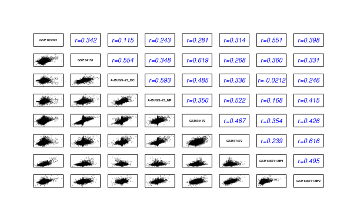

```r
panel.cor <- function(x, y, digits = 3, prefix = "", cex.cor, ...)
{
     usr <- par("usr"); on.exit(par(usr))
     par(usr = c(0, 1, 0, 1))
     r <- cor(x, y, use="pairwise.complete.obs")
     txt <- format(c(r, 0.123456789), digits = digits)[1]
     txt <- paste0("r=", txt)
     # if(missing(cex.cor)) cex.cor <- 0.8/strwidth(txt)
     # text(0.5, 0.5, txt, cex = cex.cor * r)
     text(0.5, 0.5, txt, cex=1.0, col="blue", font = 3)
}
 merged.df %>%
  set_colnames(names(all.data.list)) %>%
  pairs(., col = alpha("black", 0.2), pch=20, cex =0.1, upper.panel = panel.cor,
        xaxt='n', yaxt='n',
        text.panel = function(x,y,lab,cex,font) {text(x,y,lab, cex=0.5, font=2)})
```

### Save plot as a pdf

```r
out.file <- paste("data_out", stringr::str_replace(this.script, "\\.[Rr][Mm][Dd]$", ".pdf"), sep="/")
out.file
```

```
[1] "data_out/rank_product_01e.2NA.pdf"
```

```r
pdf(file=out.file, width = 6.7, height=4)
merged.df %>%
  set_colnames(names(all.data.list)) %>%
  pairs(., col = alpha("black", 0.2), pch=20, upper.panel = panel.cor,
        xaxt='n', yaxt='n',
        text.panel = function(x,y,lab,cex,font) {text(x,y,lab, cex=0.5, font=2)})
dev.off()
```

### Plot ranks

[figure not shown]

```r
panel.cor.spearman <- function(x, y, digits = 3, prefix = "", cex.cor, ...)
{
     usr <- par("usr"); on.exit(par(usr))
     par(usr = c(0, 1, 0, 1))
     r <- cor(x, y, use="pairwise.complete.obs", method="spearman")
     txt <- format(c(r, 0.123456789), digits = digits)[1]
     txt <- paste0("r=", txt)
     text(0.5, 0.5, txt, cex=2.5, col="purple", font = 3)
}
ranks.down.mx.2 %>%
  set_colnames(names(all.data.list)) %>%
  pairs(., col = alpha("black", 0.3), pch=18, upper.panel = panel.cor.spearman,
        xaxt='n', yaxt='n',
      text.panel = function(x,y,lab,cex,font) {text(x,y,lab, cex=3, font=2)})
```

## Calculate rank sum statistics

```r
# browseVignettes("RankProd")
# help(package="RankProd")
# help(RankProducts, package="RankProd")
```

```r
get.rank.sum <- function(mx) {
  cl.down <- rep(1, ncol(mx))
  rank.sum <- RankProd::RankProducts(
    data=mx,
    cl=cl.down,
    calculateProduct=FALSE,
    gene.names = row.names(ranks.down.mx.2)
    )
  rank.sum
}
```

```r
get.rank.sum.stats <- function(rank.sum.result) {
  # Get rank sums:
  RS <- as.data.frame(rank.sum.result$RSs) %>%
    tibble::rownames_to_column(.) %>%
    dplyr::select(1:2) %>%
    set_colnames(c("Gene", "Rank.Sum")) %>%
    arrange(Rank.Sum)

  # Get p values:
  PVAL <- as.data.frame(rank.sum.result$pval) %>%
  tibble::rownames_to_column(.) %>%
  dplyr::select(1:2) %>%
  set_colnames(c("Gene", "P.Val"))

  # Merge:
  RS.PVAL <- merge(x=RS, y=PVAL, by="Gene", all=T)

  # Adjust p values:
  RS.PVAL$P.Val.Adj <- p.adjust(RS.PVAL$P.Val, method = "fdr")

  RS.PVAL
}
```

### Rank sum stats: downregulation

```r
rank.sum.down <- get.rank.sum(ranks.down.mx.2) %>%
  get.rank.sum.stats(.)
```

```
Rank Product analysis for paired case


 done
```

```r
# class(rank.sum.down) # "data.frame"
# dim(rank.sum.down) # 11684     4
rank.sum.down %>%
  arrange(Rank.Sum) %>%
  head(., 10) %>%
  knitr::kable(., row.names = F, align=rep("l", 4), format = "html", escape = F) %>%
  kableExtra::kable_styling("striped", full_width = T)
```

| Gene | Rank.Sum | P.Val | P.Val.Adj |
| --- | --- | --- | --- |
| MS4A6A | 67.500 | 0 | 0e+00 |
| TREM2 | 114.375 | 0 | 0e+00 |
| ADORA3 | 120.000 | 0 | 0e+00 |
| CD36 | 166.000 | 0 | 0e+00 |
| FZD2 | 229.125 | 0 | 0e+00 |
| S100A4 | 230.875 | 0 | 0e+00 |
| CAMK1 | 302.875 | 0 | 1e-07 |
| GRAMD4 | 322.625 | 0 | 2e-07 |
| FUCA1 | 348.500 | 0 | 3e-07 |
| ENC1 | 367.750 | 0 | 4e-07 |

### Rank sum stats: upregulation

```r
rank.sum.up <- get.rank.sum(ranks.up.mx.2) %>%
  get.rank.sum.stats(.)
```

```
Rank Product analysis for paired case


 done
```

```r
# class(rank.sum.up) # "data.frame"
# dim(rank.sum.up) # 12786     4
rank.sum.up %>%
  arrange(Rank.Sum) %>%
  head(., 10) %>%
  knitr::kable(., row.names = F, align=rep("l", 4), format = "html", escape = F) %>%
  kableExtra::kable_styling("striped", full_width = T)
```

| Gene | Rank.Sum | P.Val | P.Val.Adj |
| --- | --- | --- | --- |
| CCL20 | 12.875 | 0 | 0 |
| CCR7 | 13.750 | 0 | 0 |
| IL1B | 31.500 | 0 | 0 |
| IDO1 | 45.250 | 0 | 0 |
| TNFAIP6 | 60.000 | 0 | 0 |
| IL6 | 62.875 | 0 | 0 |
| CXCL8 | 71.625 | 0 | 0 |
| CXCL2 | 74.750 | 0 | 0 |
| G0S2 | 76.250 | 0 | 0 |
| TRAF1 | 87.000 | 0 | 0 |

## Heatmaps for top regulated genes

([Datanovia Tutorial](https://www.datanovia.com/en/lessons/heatmap-in-r-static-and-interactive-visualization/#r-base-heatmap-heatmap))

### Heatmap: 100 most downregulated genes

```r
# nrow(subset(rank.sum.up, P.Val.Adj <= 0.05)) # 594
# nrow(subset(rank.sum.up, P.Val.Adj <= 0.01)) # 317
down.100 <- dplyr::arrange(rank.sum.down, P.Val.Adj, Rank.Sum) %>%
  head(.,100) %>% .$Gene
# down.100
mx.down.100 <- ranks.down.mx.2[down.100,] %>%
  set_colnames(names(all.data.list))
# dim(mx.down.100) # 100   5
head(mx.down.100)
```

```
       GSE103092 GSE34151 A-BUGS-23_DC A-BUGS-23_MP GSE64179 GSE67472
MS4A6A       241      2.0            4            6       10      271
TREM2        160     53.0           12           37       35       82
ADORA3       151      4.0          521           24        1       19
CD36         113    130.0           57            1      208      152
FZD2         413     34.5          171           94      219      371
S100A4       227     61.5           72           85       31      842
       GSE148731.MF1 GSE148731.MF2
MS4A6A             4             2
TREM2            307           228
ADORA3           120           120
CD36             270           398
FZD2             230           301
S100A4            43           485
```

```r
down.100.df <- as.data.frame(t(mx.down.100))
# dim(down.100.df) # 5 100
row.names(down.100.df) <- names(all.data.list)

down.100.df <- as.data.frame(t(mx.down.100)) %>%
  set_rownames(names(all.data.list)) %>%
  tibble::rownames_to_column("Dataset") %>%
  dplyr::mutate(Technology = "Microarray") %>%
  dplyr::mutate(Cell.type = "Macrophages") %>%
  dplyr::select(Dataset, Technology, Cell.type, dplyr::everything())
down.100.df$Technology[down.100.df$Dataset %in% names(rna.seq.data.list)] <- "RNA-seq"
down.100.df$Cell.type[down.100.df$Dataset %in% c("GSE64179", "A-BUGS-23_DC", "GSE34151")] <- "Dendritic cells"
down.100.df[,1:6]
```

| Dataset | Technology | Cell.type | MS4A6A | TREM2 | ADORA3 |
| --- | --- | --- | --- | --- | --- |
| GSE103092 | Microarray | Macrophages | 241 | 160 | 151 |
| GSE34151 | Microarray | Dendritic cells | 2 | 53 | 4 |
| A-BUGS-23_DC | Microarray | Dendritic cells | 4 | 12 | 521 |
| A-BUGS-23_MP | Microarray | Macrophages | 6 | 37 | 24 |
| GSE64179 | RNA-seq | Dendritic cells | 10 | 35 | 1 |
| GSE67472 | RNA-seq | Macrophages | 271 | 82 | 19 |
| GSE148731.MF1 | RNA-seq | Macrophages | 4 | 307 | 120 |
| GSE148731.MF2 | RNA-seq | Macrophages | 2 | 228 | 120 |

```r
col <- list(Technology = c("Microarray" = "yellow", "RNA-seq" = "darkgreen"),
            Cell.type = c("Macrophages" = "lightgrey", "Dendritic cells" = "black"))
ha <- ComplexHeatmap::HeatmapAnnotation(
  Technology = down.100.df$Technology,
  Cell.type = down.100.df$Cell.type,
  col=col
)
```

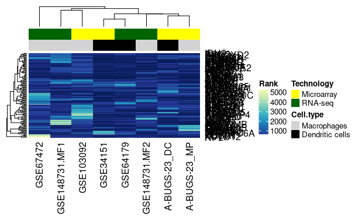

```r
# help(Heatmap, package="ComplexHeatmap")
# "YlOrRd", "YlOrBr", "YlGnBu"*, "PuBuGn", "YlGn", "RdPu"-, "PuRd"-, "BuGn"
# "Blues", "Greens", "Purples", "Oranges"
heat.cols <- colorRampPalette(RColorBrewer::brewer.pal(9, "YlGnBu"))(256) %>% rev
ComplexHeatmap::Heatmap(
  mx.down.100, name = "Rank",
  col = heat.cols,
  top_annotation = ha)
```

### Heatmap: 100 most upregulated genes

```r
up.100 <- dplyr::arrange(rank.sum.up, P.Val.Adj, Rank.Sum) %>%
  head(.,100) %>% .$Gene
head(up.100)
```

```
[1] "CCL20"   "CCR7"    "IL1B"    "IDO1"    "TNFAIP6" "IL6"
```

```r
mx.up.100 <- ranks.up.mx.2[up.100,] %>%
  set_colnames(names(all.data.list))
 dim(mx.up.100) # 100   6
```

```
[1] 100   8
```

```r
head(mx.up.100)
```

```
        GSE103092 GSE34151 A-BUGS-23_DC A-BUGS-23_MP GSE64179 GSE67472
CCL20          52      8.0            5            2        7        3
CCR7            1      4.0           21           16       34        4
IL1B           47     11.0           15           58       30       37
IDO1          159      1.0           19           10       11       68
TNFAIP6        17    165.0           45           49       37       41
IL6           126    124.5           59            6       38       17
        GSE148731.MF1 GSE148731.MF2
CCL20            13.0          13.0
CCR7             15.0          15.0
IL1B             52.0           2.0
IDO1             47.0          47.0
TNFAIP6          62.5          62.5
IL6              66.0          66.0
```

```r
up.100.df <- as.data.frame(t(mx.up.100))
# dim(down.100.df) # 5 100
row.names(up.100.df) <- names(all.data.list)

up.100.df <- as.data.frame(t(mx.up.100)) %>%
  set_rownames(names(all.data.list)) %>%
  tibble::rownames_to_column("Dataset") %>%
  dplyr::mutate(Technology = "Microarray") %>%
  dplyr::mutate(Cell.type = "Macrophages") %>%
  dplyr::select(Dataset, Technology, Cell.type, dplyr::everything())
up.100.df$Technology[up.100.df$Dataset %in% names(rna.seq.data.list)] <- "RNA-seq"
up.100.df$Cell.type[up.100.df$Dataset %in% c("GSE64179", "A-BUGS-23_DC","GSE34151")] <- "Dendritic cells"
up.100.df[,1:6]
```

| Dataset | Technology | Cell.type | CCL20 | CCR7 | IL1B |
| --- | --- | --- | --- | --- | --- |
| GSE103092 | Microarray | Macrophages | 52 | 1 | 47 |
| GSE34151 | Microarray | Dendritic cells | 8 | 4 | 11 |
| A-BUGS-23_DC | Microarray | Dendritic cells | 5 | 21 | 15 |
| A-BUGS-23_MP | Microarray | Macrophages | 2 | 16 | 58 |
| GSE64179 | RNA-seq | Dendritic cells | 7 | 34 | 30 |
| GSE67472 | RNA-seq | Macrophages | 3 | 4 | 37 |
| GSE148731.MF1 | RNA-seq | Macrophages | 13 | 15 | 52 |
| GSE148731.MF2 | RNA-seq | Macrophages | 13 | 15 | 2 |

```r
col <- list(Technology = c("Microarray" = "yellow", "RNA-seq" = "darkgreen"),
            Cell.type = c("Macrophages" = "lightgrey", "Dendritic cells" = "black"))
ha <- ComplexHeatmap::HeatmapAnnotation(
  Technology = up.100.df$Technology,
  Cell.type = up.100.df$Cell.type,
  col=col
)
```

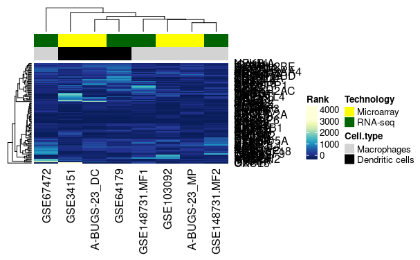

```r
# help(Heatmap, package="ComplexHeatmap")
# "YlOrRd", "YlOrBr", "YlGnBu"*, "PuBuGn", "YlGn", "RdPu"-, "PuRd"-, "BuGn"
# "Blues", "Greens", "Purples", "Oranges"
heat.cols <- colorRampPalette(RColorBrewer::brewer.pal(9, "YlGnBu"))(256) %>% rev
ComplexHeatmap::Heatmap(
  mx.up.100, name = "Rank",
  col = heat.cols,
  top_annotation = ha)
```

## Save genes

### Save top downregulated genes

```r
gs.down.01 <- rank.sum.down %>%
  dplyr::filter(P.Val.Adj <= 0.01) %>%
  use_series("Gene")
 length(gs.down.01) # 569
```

[1] 569

```r
cat("Number of consistently <b><i>down</i></b>regulated genes (p <= 0.01):<b>", length(gs.down.01), "</b>")
```

Number of consistently *down*regulated genes (p <= 0.01): **569**

```r
out.file.down.01 <- paste0("data_out/", this.script, ".down.01.txt")
cat(gs.down.01, sep="\n", file=out.file.down.01)
cat("File saved:", out.file.down.01)
```

```
File saved: data_out/rank_product_01e.2NA.Rmd.down.01.txt
```

### Save top upregulated genes

```r
gs.up.01 <- rank.sum.up %>%
  dplyr::filter(P.Val.Adj <= 0.01) %>%
  use_series("Gene")
length(gs.up.01) # 804
```

[1] 804

```r
cat("Number of consistently <b><i>up</i></b>regulated genes (p <= 0.01):<b>", length(gs.up.01), "</b>")
```

Number of consistently *up*regulated genes (p <= 0.01): **804**

```r
out.file.up.01 <- paste0("data_out/", this.script, ".up.01.txt")
cat(gs.up.01, sep="\n", file=out.file.up.01)
cat("File saved:", out.file.up.01)
```

```
File saved: data_out/rank_product_01e.2NA.Rmd.up.01.txt
```

## Session info

```r
Sys.time()
```

```
[1] "2020-07-16 15:23:02 BST"
```

```r
# sessionInfo()
devtools::session_info()
```

|  | setting | value |
| --- | --- | --- |
| version | version | R version 3.5.3 (2019-03-11) |
| os | os | CentOS Linux 7 (Core) |
| system | system | x86_64, linux-gnu |
| ui | ui | RStudio |
| language | language | (EN) |
| collate | collate | en_GB.UTF-8 |
| ctype | ctype | en_GB.UTF-8 |
| tz | tz | Europe/London |
| date | date | 2020-07-16 |